# Ford GoBike System Data

## by Abdullah Adel El damanhoury

## Investigation Overview

> There are 183412 trips in the dataset with 16 features (duration_sec , start_time , end_time , start_station_id , start_station_name , start_station_latitude , start_station_longitude , end_station_id , end_station_name , end_station_latitude , end_station_longitude , bike_id , user_type , member_birth_year , member_gender , bike_share_for_all_trip)

## Dataset Overview

> This dataset includes 183412 trips includes information about individual rides with 18 features(age and Day columns aer created) such as locations, time, and user attributes .

## (Visualization 1)

### Distribution of duration in seconds

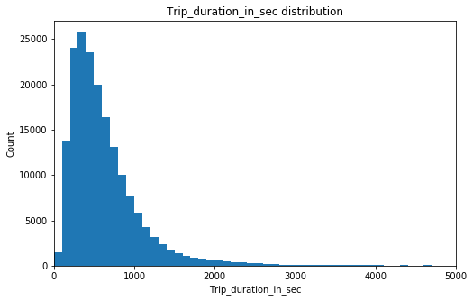

## (Visualization 2)

### Correlation between 'duration_sec' and 'age'

> What is correlation between 'duration_sec' and 'age' columns ?

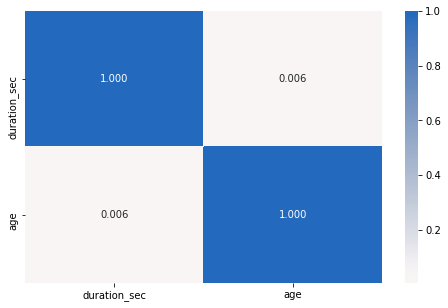

> Although there is slightly positive correlation between age and duration but it doesn't mean any thing . As a result i will consider that there is no any positive relationship

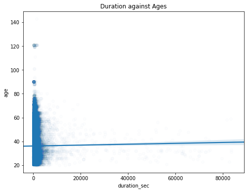

## (Visualization 3)

### Finding out Trip duration_sec vs Day vs member_gender

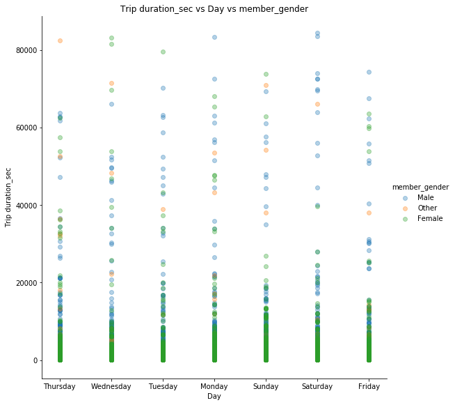

[output not shown]